# Análise Espacial da Dengue no Estado da Bahia

# 2 Introdução

A dengue é atualmente a arbovirose mais frequente no mundo, acometendo milhões de pessoas a cada ano em zonas tropicais e subtropicais. Como integrante do grupo das arboviroses, que compreende doenças virais transmitidas por artrópodes hematófagos, como mosquitos e carrapatos, a dengue destaca-se por sua ampla distribuição geográfica e elevado número de casos. Segundo a Organização Pan Americana da Saúde (ORGANIZAÇÃO PAN-AMERICANA DA SAÚDE, 2016), estima-se que entre 50 e 100 milhões de infecções por dengue ocorram anualmente em todo o mundo. Sua transmissão ocorre principalmente por meio do mosquito Aedes aegypti, mais conhecido como mosquito da dengue, cuja proliferação e capacidade de disseminação são influenciadas por fatores climáticos, ambientais e socioeconômicos, tornando a dinâmica da doença um fenômeno complexo e heterogêneo entre diferentes regiões.

No cenário brasileiro, o país figura entre os mais afetados pela dengue nas Américas. Conforme reportado pelo Ministério da Saúde (MINISTÉRIO DA SAÚDE, 2024), o Brasil registrou, em 2024, um total de 6.484.890 casos prováveis de dengue e 5.972 óbitos, correspondendo a uma incidência de aproximadamente 3.194 casos por 100 mil habitantes. Tais indicadores evidenciam a magnitude da circulação da doença no território nacional e reforçam os desafios enfrentados pelos serviços de vigilância e controle epidemiológico.

A dengue é uma doença infecciosa febril aguda transmitida principalmente pelo mosquito *Aedes aegypti*, principal vetor da doença em áreas urbanas. Esse mosquito apresenta características morfológicas que facilitam sua identificação, destacando-se pela presença de marcas brancas contrastantes distribuídas pelo corpo, conforme ilustrado na Figura 1.

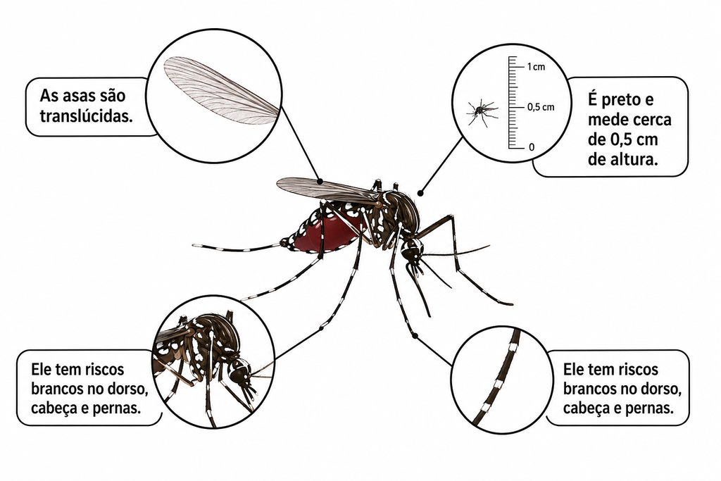

Figura 1: Morfologia do *Aedes aegypti*.

A capacidade de proliferação do mosquito decorre, em parte, de seu ciclo de vida relativamente curto e altamente adaptável aos ambientes urbanos. A fêmea deposita seus ovos em recipientes contendo água parada, onde as larvas eclodem após alguns dias e evoluem para a fase de pupa ainda no ambiente aquático, emergindo posteriormente como mosquitos adultos aptos à transmissão do vírus. Conforme ilustrado na Figura 2, esse ciclo biológico pode ser completado em menos de duas semanas quando submetido a condições climáticas favoráveis.

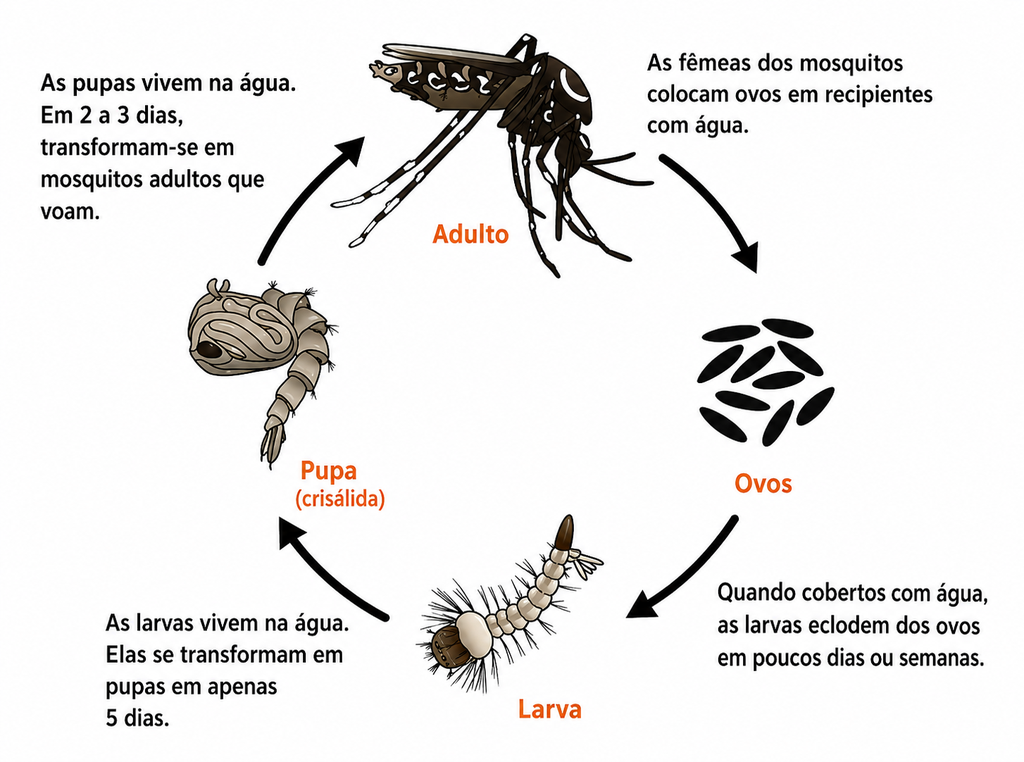

Figura 2: Ciclo de vida do *Aedes aegypti*, desde a postura dos ovos até o mosquito adulto.

A transmissão do vírus ocorre exclusivamente por meio da picada de fêmeas infectadas do Aedes aegypti. O mosquito adquire o agente viral ao se alimentar do sangue de uma pessoa infectada e, após um período de incubação extrínseca em seu organismo, torna-se capaz de transmitir o vírus a um indivíduo suscetível em uma picada subsequente. Esse processo de transmissão é ilustrado na Figura 3.

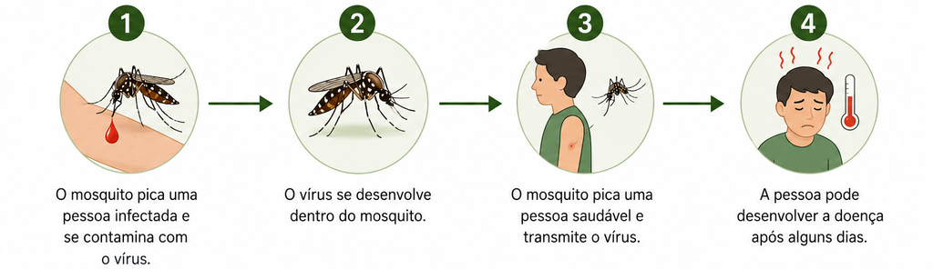

Figura 3: Mecanismo de transmissão do vírus da dengue pelo *Aedes aegypti*.

A presença e a proliferação do agente transmissor estão intimamente associadas a fatores climáticos, ambientais, sociais e territoriais, conferindo à dengue uma dinâmica espaço-temporal. Nesse contexto, o estado da Bahia constitui um cenário particularmente relevante para o presente estudo, por ser a maior unidade federativa da região Nordeste em extensão territorial e a quarta mais populosa do país, abrangendo 417 municípios. Sua expressiva diversidade climática, ambiental e demográfica favorece a ocorrência de padrões heterogêneos de transmissão da doença, tornando o estado uma área de interesse para estudos epidemiológicos com abordagem espacial.

A relevância da análise da dengue no contexto baiano também é evidenciada por estudos prévios que identificaram padrões espaciais e temporais significativos da doença no estado. Segundo Silva e Santos (SILVA; SANTOS, 2021), a distribuição dos casos de dengue na Bahia apresenta heterogeneidade espacial, com concentrações mais intensas em determinadas regiões geográficas. Tais evidências reforçam a importância de investigar a dinâmica da doença considerando as particularidades socioespaciais dos municípios baianos.

O objetivo central desta análise é avaliar o comportamento espaço-temporal da dengue no estado da Bahia entre 2021 e 2024, utilizando como variável principal a taxa de incidência por 100 mil habitantes. Essa medida permite minimizar distorções decorrentes das diferenças de tamanho populacional entre os municípios, possibilitando uma avaliação mais adequada do impacto relativo da doença em cada região. Nesse contexto, a incorporação de técnicas de Estatística Espacial aplicadas a dados de área supera as limitações das análises puramente descritivas, permitindo investigar a dinâmica espaço-temporal da incidência da dengue, testar a existência de autocorrelação espacial global, identificar padrões locais de associação espacial e mapear áreas com maior vulnerabilidade à ocorrência da doença. Dessa forma, pretende-se produzir evidências que possam subsidiar ações de vigilância epidemiológica, controle vetorial e planejamento em saúde pública, contribuindo para uma gestão mais eficiente dos recursos destinados à prevenção e ao controle da dengue.

# 3 Fundamentação Teórica

Nesta seção, apresentam-se os fundamentos conceituais e as formulações matemáticas das principais métricas e técnicas utilizadas ao longo da análise. São discutidos os indicadores epidemiológicos empregados para mensurar a ocorrência da dengue, bem como os métodos de Estatística Espacial de Área utilizados para investigar padrões de dependência espacial e identificar aglomerados espaciais da doença.

## 3.1 Análise Exploratória dos Dados (EDA)

Inicialmente, a analise é conduzida por meio da Análise Exploratória dos Dados (EDA: Exploratory Data Analysis), constituindo-se uma etapa fundamental para a compreensão preliminar do comportamento da variável alvo. Neste trabalho, a distribuição das taxas de incidência de dengue observadas nos municípios baianos é caracterizada, para cada ano do período analisado, por meio de estatísticas descritivas que permitem avaliar sua tendência central, dispersão e variabilidade.

Entre as medidas de tendência central, utiliza-se a média aritmética, definida por:

$$\bar{x} = \frac{1}{n} \sum_{i=1}^{n} x_i$$

A dispersão dos dados é avaliada por meio do desvio padrão:

$$s = \sqrt{\frac{1}{n-1} \sum_{i=1}^{n} (x_i - \bar{x})^2}$$

e do coeficiente de variação, dado por:

$$CV = \frac{s}{\bar{x}} \times 100$$

Além dessas medidas, também são apresentados os valores mínimo e máximo observados, bem como os quartis, que dividem a distribuição ordenada em quatro partes iguais. Dado o conjunto de valores ordenados $x_{(1)} \leq x_{(2)} \leq \cdots \leq x_{(n)}$, os quartis são definidos como se segue.

O primeiro quartil ($Q_1$), correspondente ao percentil 25, é dado por:

$$Q_1 = x_{\left(\lceil n/4 \rceil\right)}$$

A mediana ($Q_2$), correspondente ao percentil 50, é definida por:

$$Q_2 = \begin{cases} x_{(m+1)}, & \text{se } n = 2m+1 \\ \dfrac{x_{(m)} + x_{(m+1)}}{2}, & \text{se } n = 2m \end{cases}$$

ou seja, quando o número de observações é ímpar, a mediana corresponde ao valor central da distribuição ordenada e quando é par, corresponde à média aritmética dos dois valores centrais.

O terceiro quartil ($Q_3$), correspondente ao percentil 75, é dado por:

$$Q_3 = x_{\left(\lceil 3n/4 \rceil\right)}$$

Essas estatísticas descrevem a variabilidade das taxas de incidência entre os municípios baianos em cada ano, permitindo identificar diferenças na magnitude dos valores, possíveis assimetrias e a presença de observações extremas.

## 3.2 Taxa de Incidência

A taxa de incidência constitui a principal medida epidemiológica utilizada neste estudo. Esse indicador expressa a ocorrência relativa da doença na população sob risco, independentemente do tamanho absoluto da população de cada município, possibilitando comparações diretas entre unidades territoriais com portes populacionais distintos. Trata-se de uma variável quantitativa contínua, mensurada na escala de razão, que pode ser entendida como uma superfície contínua definida sobre o espaço geográfico — conceito fundamental em Estatística Espacial para a modelagem de fenômenos distribuídos no território (CRESSIE, 1993; WALLER; GOTWAY, 2004). Sua formulação é dada por:

$$\text{Taxa}_{i,t} = \frac{C_{i,t}}{P_{i,t}} \times 100.000$$

em que $C_{i,t}$ representa o número de casos novos registrados no município $i$ durante o ano $t$, e $P_{i,t}$ corresponde à população residente no mesmo município e período. O fator multiplicativo de 100.000 expressa o resultado em casos por 100 mil habitantes, convenção amplamente adotada em estudos epidemiológicos para facilitar a interpretação dos resultados e a comparação entre diferentes localidades (RIPSA – REDE INTERAGENCIAL DE INFORMAÇÕES PARA A SAÚDE, 2000).

## 3.3 Matriz de Vizinhança Espacial

A análise de autocorrelação espacial requer a definição prévia de uma estrutura de vizinhança que formalize as relações de proximidade entre as unidades espaciais (PFEIFFER *et al.*, 2008). Essas relações são representadas por uma matriz de pesos espaciais:

$$W = [w_{ij}]_{n\times n}$$

de dimensão $(n \times n)$, na qual cada elemento $(w_{ij})$ descreve a interação espacial entre as unidades (i) e (j). Por convenção, os elementos da diagonal principal são iguais a zero $(w_{ii}=0)$, uma vez que uma unidade espacial não é considerada vizinha de si própria.

Neste estudo, utilizou-se a matriz de contiguidade do tipo Queen (Rainha), na qual são considerados vizinhos todos os polígonos que compartilham ao menos uma fronteira ou vértice em comum. Assim, para um conjunto de (n) municípios, os pesos espaciais são definidos como:

$$w_{ij} =
\left\{
\begin{array}{l}
1, & \text{se } i \text{ e } j \text{ são vizinhos} \\
0, & \text{c. c.}
\end{array}
\right.$$

A matriz é então padronizada por linha (row-standardized), de modo que a soma dos elementos de cada linha seja igual a 1:

$$w_{ij}^{*} = \frac{w_{ij}}{\sum_j w_{ij}}$$

Essa padronização garante que o lag espacial de cada observação seja interpretado como uma média ponderada dos valores observados nos municípios vizinhos, tornando comparáveis unidades espaciais com diferentes números de adjacências.

## 3.4 Índice de Moran Global

O Índice de Moran Global é uma estatística amplamente utilizada para quantificar o grau de autocorrelação espacial presente em uma variável contínua distribuída em unidades geográficas (ANSELIN, 1995). Seu cálculo é dado por:

$$I = \frac{n \sum_{i} \sum_{j} w_{ij} (y_i - \bar{y})(y_j - \bar{y})}{\sum_{i}(y_i - \bar{y})^2 \sum_{i} \sum_{j} w_{ij}}$$

em que $n$ representa o número de unidades espaciais (municípios), $w_{ij}$ corresponde aos elementos da matriz de pesos espaciais, $y_i$ e $y_j$ representam os valores observados da variável de interesse nas unidades $i$ e $j$, respectivamente, e $\bar{y}$ denota a média global da variável.

O Índice de Moran assume, em geral, valores compreendidos no intervalo $[-1, 1]$. Nesse contexto, valores positivos indicam autocorrelação espacial positiva, sugerindo que municípios com altas taxas de incidência tendem a estar próximos de outros municípios com altas taxas, enquanto municípios com baixas taxas tendem a se agrupar com municípios de baixas taxas. Por outro lado, valores negativos indicam autocorrelação espacial negativa, caracterizando um padrão de dispersão espacial. Já valores próximos de zero sugerem ausência de dependência espacial significativa, sendo compatíveis com um padrão aleatório de distribuição.

O teste de hipóteses associado ao Índice de Moran é formulado como:

$$\left\{
\begin{array}{l}
H_0: I = 0 \\[6pt]
\quad\text{vs} \\[6pt]
H_1: I \neq 0
\end{array}
\right.$$

em que a hipótese nula afirma que o Índice de Moran é igual a zero, ou seja, os valores da variável se distribuem de forma espacialmente aleatória entre as unidades geográficas (ausência de autocorrelação espacial). A hipótese alternativa indica a presença de autocorrelação espacial — positiva, quando municípios semelhantes tendem a se agrupar, ou negativa, quando valores distintos tendem a se alternar no espaço.

A significância estatística do índice foi avaliada por meio do teste de permutação de Monte Carlo (GOOD, 2005; HOPE, 1968), procedimento que consiste em redistribuir aleatoriamente os valores da variável entre as unidades espaciais em um grande número de permutações, recalculando o Índice de Moran a cada etapa e comparando o valor observado com a distribuição empírica resultante. Por não depender de pressupostos de normalidade, esse método é particularmente adequado para dados epidemiológicos, que frequentemente apresentam distribuições assimétricas (BIVAND; PEBESMA; GÓMEZ-RUBIO, 2013).

## 3.5 Indicador Local de Associação Espacial (LISA)

O Indicador Local de Associação Espacial (LISA: Local Indicators of Spatial Association), proposto por (ANSELIN, 1995), decompõe a autocorrelação espacial global em contribuições locais, permitindo identificar padrões de associação espacial em nível municipal (ALMEIDA; MEDRONHO; VALENCIA, 2009). O Índice de Moran Local para cada observação $i$ é calculado como:

$$I_i = \frac{(y_i - \bar{y})}{\sigma^2} \sum_{j} w_{ij} (y_j - \bar{y})$$

em que $\sigma^2$ representa a variância da variável em análise.

A interpretação do LISA é realizada por meio do diagrama de dispersão de Moran, que classifica cada unidade espacial em um dos quatro quadrantes de associação espacial:

1. Alto-Alto (AA ou hotspot): município com alta taxa de incidência rodeado por municípios também com altas taxas, caracterizando um aglomerado espacial de alto risco.
2. Baixo-Baixo (BB ou coldspot): município com baixa taxa de incidência rodeado por municípios também com baixas taxas, caracterizando um aglomerado espacial de baixo risco.
3. Alto-Baixo (AB): município com alta taxa de incidência rodeado por municípios com baixas taxas, caracterizando um outlier espacial positivo.
4. Baixo-Alto (BA): município com baixa taxa de incidência rodeado por municípios com altas taxas, caracterizando um outlier espacial negativo.

A significância estatística dos indicadores locais é avaliada por meio de testes de permutação condicional, sob as hipóteses:

$$\left\{
\begin{array}{l}
H_0: I_i = 0 \\[6pt]
\quad\text{vs} \\[6pt]
H_1: I_i \neq 0
\end{array}
\right.$$

em que a hipótese nula afirma que o indicador local do município $i$ é igual a zero, ou seja, não há associação espacial entre o valor observado nesse município e os valores de sua vizinhança (padrão local aleatório). A hipótese alternativa indica a existência de associação espacial local significativa, seja de agrupamento (municípios semelhantes adjacentes) ou de contraste (outlier espacial).

Com base nesse critério, foram considerados estatisticamente significativos apenas os municípios com $p$-valor inferior ao nível de significância de $\alpha = 0,05$. Consequentemente, as demais observações são classificadas como não significativas e, portanto, não são interpretadas como evidências de associação espacial local.

# 4 Materiais e Métodos

## 4.1 Fonte e Natureza dos Dados

Os dados de dengue utilizados no estudo foram obtidos por meio do Sistema de Informação de Agravos de Notificação (SINAN), disponibilizado pela Secretaria da Saúde do Estado da Bahia (SESAB) através da plataforma TABNET. O SINAN constitui uma das principais bases de vigilância epidemiológica do país, reunindo notificações de doenças e agravos registradas pelos serviços de saúde públicos e privados em todo o território nacional (MINISTÉRIO DA SAÚDE, 2016).

Embora a série histórica disponível compreenda o período de 2007 a 2025, optou-se por realizar as análises espaciais considerando os anos de 2021 a 2024. A escolha desse intervalo foi motivada pelo aumento observado na incidência da dengue ao longo desses anos, culminando em 2024, que apresentou o maior número de casos do período analisado. Foram utilizados dados referentes ao número de casos de dengue segundo o município de infecção para os 417 municípios do estado da Bahia. A utilização do local de infecção permitiu representar espacialmente o provável local de ocorrência da transmissão da doença, aspecto relevante para estudos com enfoque epidemiológico e espacial.

Por se tratar de uma análise espacial de área, os dados foram agregados em nível municipal, considerando cada município como unidade espacial de análise. Para cada ano do período estudado, foi construída uma base contendo o total de casos registrados em cada município.

Os dados populacionais foram obtidos junto ao Instituto Brasileiro de Geografia e Estatística (IBGE), utilizando-se as estimativas populacionais municipais correspondentes a cada ano analisado. Essas informações foram empregadas no cálculo das taxas de incidência por 100 mil habitantes, permitindo a comparação entre municípios com diferentes tamanhos populacionais.

## 4.2 Área de Estudo

O estado da Bahia está localizado na região Nordeste do Brasil, sendo a maior unidade federativa da região em extensão territorial, com aproximadamente 564.760 km², e uma das mais populosas do país. Além disso, o estado é composto por 417 municípios, distribuídos em diferentes contextos geográficos, climáticos, demográficos e socioeconômicos.

A Bahia apresenta elevada heterogeneidade territorial, abrangendo desde áreas densamente urbanizadas, como a Região Metropolitana de Salvador, até municípios predominantemente rurais localizados no interior do estado. Além disso, a diversidade de condições climáticas, variando entre regiões litorâneas úmidas e áreas semiáridas, influencia diretamente fatores ambientais relacionados à proliferação do mosquito *Aedes aegypti*.

## 4.3 Processamento e Análise dos Dados

### 4.3.1 Cálculo das Taxas de Incidência

Inicialmente, os dados de casos de dengue e as estimativas populacionais municipais foram organizados e integrados por município e ano de referência. Em seguida, foi calculada a taxa de incidência de dengue para cada município e ano analisado, utilizando-se a razão entre o número de casos registrados e a população residente, multiplicada por 100 mil habitantes, conforme a formulação apresentada na seção de Fundamentação Teórica.

A utilização da taxa de incidência, em substituição aos números absolutos de casos, permite padronizar os resultados em relação ao tamanho populacional dos municípios, possibilitando comparações mais adequadas entre localidades com diferentes contingentes populacionais.

Durante a etapa de preparação dos dados, foram excluídos registros com informações geográficas ausentes ou inconsistentes quanto ao município de infecção, garantindo a correta associação dos casos às respectivas unidades espaciais. Após o processamento, foram obtidas bases anuais contendo as taxas de incidência para os 417 municípios do estado da Bahia nos anos de 2021, 2022, 2023 e 2024.

As etapas subsequentes de análise espacial foram fundamentadas em referências consolidadas da literatura de Estatística Espacial e Epidemiologia Espacial, especialmente no que se refere à análise de dados de área, medidas de autocorrelação espacial e identificação de padrões locais de associação (MEDEIROS *et al.*, 2019; MORAGA, 2023; OLINDA *et al.*, 2013).

### 4.3.2 Estrutura de Vizinhança Espacial

A estrutura de dependência espacial foi definida a partir da malha municipal do estado da Bahia, obtida em formato shapefile. Com base nessa representação geográfica, foi construída uma matriz de pesos espaciais do tipo Queen (Rainha), na qual são considerados vizinhos todos os municípios que compartilham ao menos uma fronteira ou vértice em comum. Posteriormente, a matriz foi padronizada por linha (row-standardized), conforme descrito na seção de **Fundamentação Teórica**, permitindo que o lag espacial fosse interpretado como uma média ponderada dos valores observados nos municípios vizinhos.

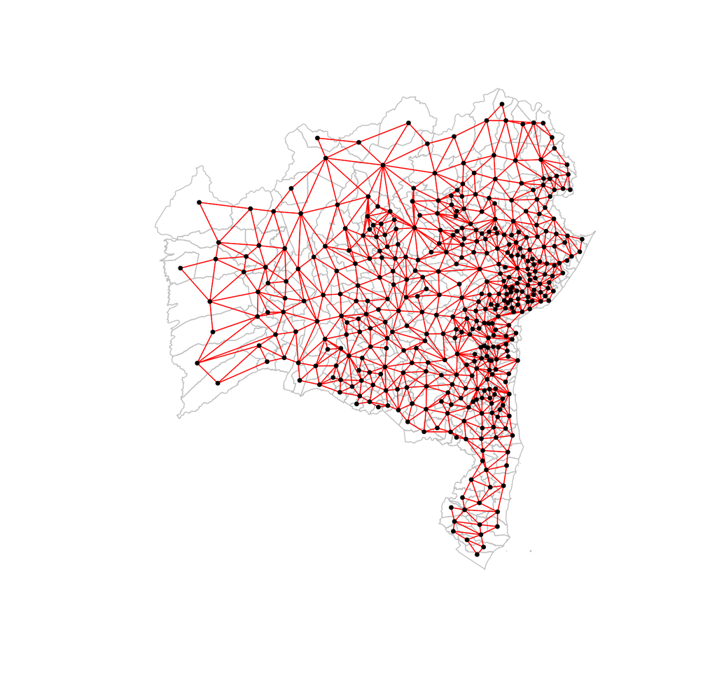

Figura 4: Matriz de conectividade: Contiguidade Queen.

### 4.3.3 Testes de Autocorrelação Espacial

Para cada ano do recorte temporal adotado (2021 a 2024), foi calculado o Índice de Moran Global com o objetivo de avaliar a existência de autocorrelação espacial na distribuição da taxa de incidência de dengue entre os municípios baianos. A significância estatística do índice foi avaliada por meio de testes de permutação de Monte Carlo com 999 simulações. Esse número é amplamente adotado na literatura de análise espacial por produzir distribuições empíricas estáveis e permitir a obtenção de p-valores com resolução mínima de 0,001, suficiente para os níveis de significância convencionalmente utilizados em estudos epidemiológicos (BIVAND; PEBESMA; GÓMEZ-RUBIO, 2013; GOOD, 2005).

O procedimento consiste em redistribuir aleatoriamente os valores observados entre as unidades espaciais, recalculando o índice a cada permutação para gerar uma distribuição empírica sob as hipóteses:

$$\left\{
\begin{array}{l}
H_0: I = 0 \\[6pt]
\quad\text{vs} \\[6pt]
H_1: I \neq 0
\end{array}
\right.$$

em que a hipótese nula afirma distribuição espacialmente aleatória e a hipótese alternativa indica presença de autocorrelação espacial, positiva ou negativa. A comparação entre o valor observado e a distribuição gerada pelas permutações permitiu obter o respectivo p-valor, sem a necessidade de pressupostos paramétricos sobre os dados.

### 4.3.4 Identificação de Padrões Locais de Associação

Os Indicadores Locais de Associação Espacial (LISA) foram calculados para cada ano do recorte temporal adotado (2021 a 2024), com o objetivo de identificar padrões locais de autocorrelação espacial na distribuição da taxa de incidência de dengue entre os municípios baianos. A significância estatística dos indicadores locais foi avaliada por meio de testes de permutação, adotando-se nível de significância de 5%.

Cada município foi classificado em uma das categorias do diagrama de dispersão de Moran (i, ii, iii e iv), permitindo a identificação e a representação cartográfica de aglomerados espaciais (clusters) e observações atípicas (outliers) na distribuição da incidência da dengue.

## 4.4 Ferramentas de Análise

Toda a análise foi realizada no software R, versão 4.5.3 (R CORE TEAM, 2024), utilizando o ambiente de desenvolvimento integrado RStudio. Foram empregados pacotes especializados para as etapas de processamento, análise e visualização dos dados.

O pacote sf foi utilizado para leitura, manipulação e análise de dados espaciais vetoriais (shapefiles). Foi empregado o pacote spdep para a construção das matrizes de vizinhança e no cálculo das medidas de autocorrelação espacial, incluindo o Índice de Moran Global e os Indicadores Locais de Associação Espacial (LISA). Para a elaboração dos gráficos e mapas temáticos, foram utilizados os pacotes ggplot2 e tmap.

As etapas de manipulação e transformação dos dados foram realizadas com os pacotes dplyr e tidyr, enquanto a geração de tabelas e relatórios dinâmicos foi conduzida com os pacotes knitr e kableExtra.

A redação e compilação do relatório foram realizadas por meio do Quarto, permitindo a integração entre código, resultados, gráficos e texto em um único documento reprodutível.

# 5 Resultados e Discussão

## 5.1 Evolução Histórica (2007-2025)

Para compreender o comportamento temporal da doença antes de aprofundar a análise espacial, foi inicialmente examinada a série histórica completa de dados disponíveis para o estado da Bahia.

As Figuras (Figura 5 e Figura 6) apresentam a evolução anual do total absoluto de casos registrados e da taxa de incidência no período de 2007 a 2025, incluindo dados preliminares referentes a 2025.

**Casos Absolutos**

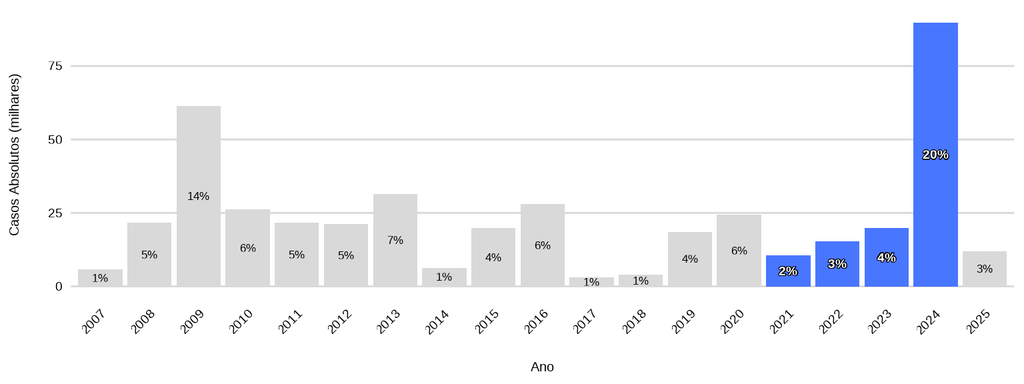

Figura 5: Evolução do total de casos absolutos de Dengue no Estado da Bahia (2007-2025).

**Taxa Média**

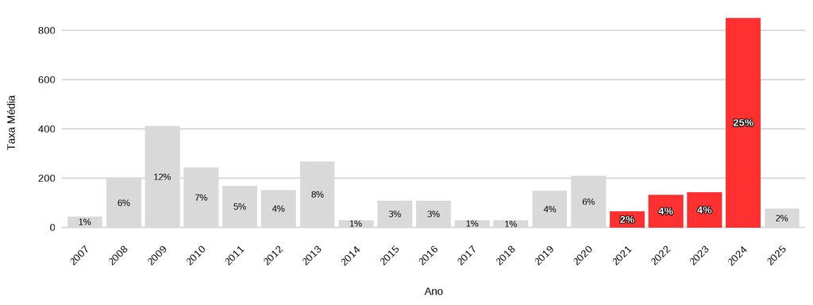

Figura 6: Evolução da taxa média de incidência de dengue no estado da Bahia (2007–2025)

É possível observar a ocorrência de picos epidêmicos em intervalos de aproximadamente três a quatro anos, padrão frequentemente relatado na literatura sobre a dinâmica de transmissão da dengue e associado à circulação de diferentes sorotipos virais na população (ARAÚJO; MELO; MORAES, 2020; HALSTEAD, 2007).

Diante do agravamento do cenário epidemiológico observado a partir de 2021, culminando em um expressivo aumento no número de casos em 2024, o presente estudo concentra as análises descritivas e espaciais no período de 2021 a 2024, considerado o intervalo de maior interesse para a investigação dos padrões recentes de incidência da dengue no estado da Bahia.

### 5.1.1 Recorte Temporal (2021-2024)

Com o recorte temporal definido, foram analisados o número total de casos registrados e a taxa média de incidência observada nos municípios baianos entre 2021 e 2024. As Figuras (Figura 7 e Figura 8) apresentam a evolução dessas medidas ao longo do período.

**Casos Absolutos**

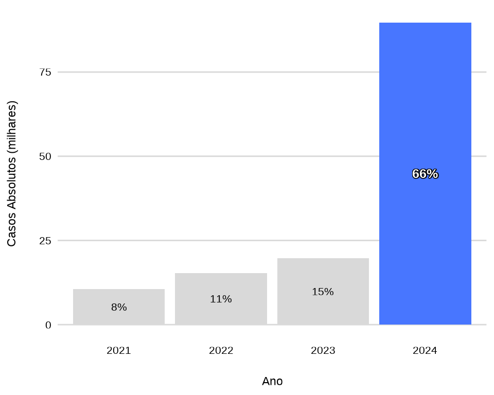

Figura 7: Distribuição dos Casos de Dengue (2021–2024).

**Taxa Média**

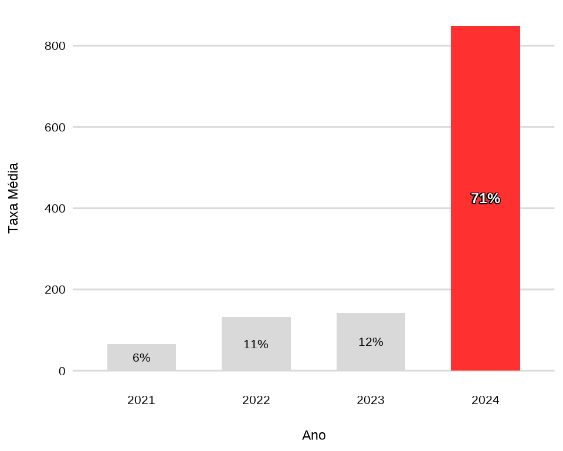

Figura 8: Taxa Média de Incidência de Dengue (2021–2024).

Observa-se crescimento tanto no número de casos quanto na taxa média de incidência entre 2021 e 2024. O aumento foi mais intenso a partir de 2023, culminando em 2024, ano que concentrou a maior parcela dos casos registrados e os maiores valores médios de incidência entre os municípios analisados.

Esse comportamento reforça o agravamento do cenário epidemiológico já observado na série histórica e evidencia a relevância do período selecionado para o estudo dos padrões espaciais da dengue no estado da Bahia.

## 5.2 Análise Exploratória dos Dados

Além disso, foram analisadas as estatísticas descritivas das taxas de incidência de dengue observadas nos 417 municípios baianos entre 2021 e 2024. A Tabela 1 apresenta as principais estatísticas descritivas da distribuição dessas taxas para cada ano do período estudado.

Tabela 1: Estatísticas descritivas da taxa de incidência de dengue (por 100 mil hab.) — Bahia, 2021 a 2024.

| ano | min | q1 | mediana | media | q3 | max | sd | cv% |
| --- | --- | --- | --- | --- | --- | --- | --- | --- |
| 2021 | 0 | 0.00 | 1.02 | 65.41 | 12.28 | 2592.28 | 251.48 | 384.45 |
| 2022 | 0 | 0.00 | 8.88 | 131.69 | 58.26 | 2860.15 | 360.95 | 274.08 |
| 2023 | 0 | 0.89 | 14.14 | 142.46 | 78.93 | 4917.68 | 444.99 | 312.36 |
| 2024 | 0 | 31.32 | 160.90 | 849.21 | 843.37 | 15586.75 | 1768.83 | 208.29 |

**Nota:** $\bar{x}$ = média aritmética; $s$ = desvio padrão; $CV$ = coeficiente de variação (%); $Q_1$ = primeiro quartil (percentil 25); $Q_2$ = mediana (percentil 50); $Q_3$ = terceiro quartil (percentil 75); Mín. = valor mínimo observado; Máx. = valor máximo observado. Todas as taxas expressas em casos por 100 mil habitantes.

Os resultados mostram um aumento das taxas de incidência de dengue ao longo do período analisado, com destaque para 2024, que apresentou os maiores valores de média, mediana e dispersão. Em todos os anos observa-se elevada variabilidade entre os municípios, evidenciada pelos valores do desvio-padrão e do coeficiente de variação.

A diferença observada entre média e mediana sugere a presença de assimetria à direita na distribuição das taxas de incidência. Isso indica que a ocorrência da dengue não se distribuiu de forma homogênea entre os municípios, havendo localidades com valores substancialmente superiores aos observados na maior parte do estado.

Observa-se ainda um crescimento gradual da média das taxas de incidência ao longo do período. Em 2021, a taxa média foi de 65,41 casos por 100 mil habitantes, passando para 131,69 em 2022 e 142,46 em 2023. Em 2024, esse valor atingiu 849,21 casos por 100 mil habitantes, evidenciando uma intensificação da incidência da doença em relação aos anos anteriores.

O aumento dos valores máximos observados e do desvio-padrão ao longo dos anos, especialmente em 2024, indica um crescimento da heterogeneidade entre os municípios baianos, com algumas localidades apresentando taxas de incidência muito superiores à média estadual.

### 5.2.1 Dispersão e Distribuição das Taxas Municipais

Para complementar a análise descritiva, foram construídos *Diagramas de Caixas* (boxplots) para cada ano do período estudado, apresentados na Figura 9, permitindo visualizar a distribuição das taxas de incidência entre os municípios, bem como medidas de posição, dispersão e possíveis valores discrepantes (outliers).

O eixo vertical foi representado em escala logarítmica (log10), devido à elevada amplitude observada nas taxas de incidência ao longo do período analisado. Em todos os anos, verificam-se municípios com valores muito superiores aos demais, o que dificulta a visualização da distribuição dos dados em escala original. A transformação logarítmica é amplamente recomendada para dados com distribuição assimétrica à direita e grande variação de magnitude, como taxas epidemiológicas, pois estabiliza a variância e permite uma comparação visual mais equilibrada das distribuições (TUKEY, 1977; WALLER; GOTWAY, 2004). Dessa forma, a transformação permitiu uma representação mais equilibrada das taxas, facilitando a comparação das distribuições entre os anos analisados.

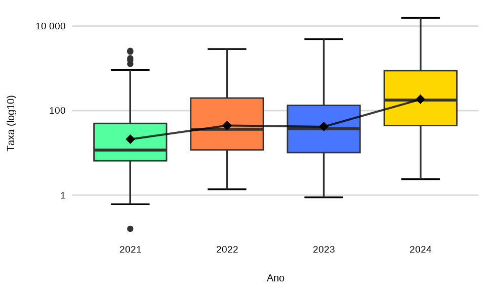

Figura 9: Distribuição das Taxas de Dengue por município em escala logarítmica (2021-2024).

A partir da análise dos diagramas, observa-se um crescimento gradual da distribuição das taxas de incidência para valores mais elevados ao longo do período estudado. Esse comportamento é evidenciado pelo aumento da mediana e pela elevação dos quartis, especialmente em 2024, indicando que a incidência da dengue cresceu na maior parte dos municípios baianos.

Verifica-se também um aumento da dispersão das taxas ao longo dos anos, com destaque para 2024, cuja distribuição apresenta maior amplitude em relação aos anos anteriores, sugerindo que o crescimento da incidência não ocorreu de maneira uniforme entre os municípios, havendo localidades que registraram aumentos mais intensos que outras.

Quanto aos valores discrepantes, observam-se alguns outliers apenas em 2021, tanto acima quanto abaixo dos limites definidos pelo boxplot a partir do intervalo interquartílico. Nos demais anos, embora existam municípios com taxas elevadas, esses valores permanecem dentro da amplitude esperada da distribuição.

De modo geral, os resultados indicam mudanças na distribuição das taxas de incidência entre os anos analisados, justificando a aplicação das técnicas de autocorrelação espacial apresentadas nas próximas seções, com o objetivo de investigar a existência de padrões espaciais na ocorrência da dengue entre os municípios baianos.

## 5.3 Análise Espacial (2021–2024)

Os resultados apresentados até o momento evidenciam a existência de diferenças nas taxas de incidência de dengue entre os municípios baianos. Embora a análise descritiva permita identificar o aumento da incidência ao longo do período e a variabilidade existente entre os municípios, ela não permite verificar se municípios com comportamentos semelhantes tendem a se localizar próximos uns dos outros no espaço geográfico.

A análise espacial constitui uma ferramenta amplamente utilizada em estudos epidemiológicos, pois permite investigar a distribuição geográfica dos eventos de interesse e identificar possíveis padrões de concentração espacial (ARAÚJO; MELO; MORAES, 2020). Nesse contexto, torna-se necessária a incorporação da componente espacial à análise das taxas de incidência de dengue observadas no estado da Bahia.

Inicialmente, são apresentados mapas temáticos das taxas de incidência com o objetivo de explorar visualmente sua distribuição no território baiano e identificar possíveis áreas de maior e menor ocorrência da doença. Em seguida, são aplicadas medidas de autocorrelação espacial, por meio do Índice de Moran Global e dos Indicadores Locais de Associação Espacial (LISA), permitindo avaliar formalmente a existência de dependência espacial e identificar possíveis aglomerados de incidência entre os municípios.

### 5.3.1 Mapas de Distribuição Espacial (2021-2024)

**Quantis**

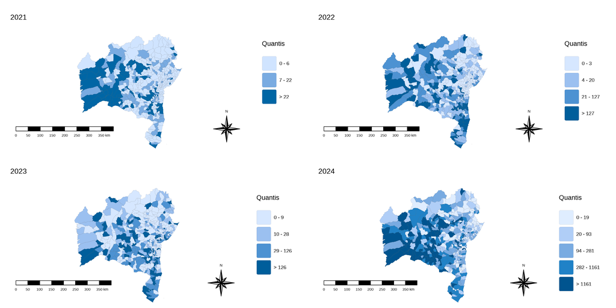

Figura 10: Distribuição espacial da dengue na Bahia (2021-2024) por quantis.

A Figura 10 apresenta a distribuição espacial das taxas de incidência de dengue nos municípios baianos por meio da classificação em quantis. Essa representação permite visualizar a posição relativa de cada município dentro da distribuição observada em cada ano, destacando as áreas com maiores e menores taxas de incidência.

Observa-se que, ao longo do período analisado, ocorre um aumento gradual no número de municípios classificados nas categorias de maior incidência. Em 2021, os municípios com taxas mais elevadas encontram-se distribuídos de forma mais pontual pelo estado. Nos anos seguintes, especialmente em 2024, verifica-se uma expansão dessas áreas, com maior concentração de municípios pertencentes às classes superiores de incidência.

Também é possível notar que os municípios com maiores taxas não se distribuem de forma homogênea pelo território baiano. Em diversos momentos, observa-se a formação de áreas contíguas com valores semelhantes, sugerindo a existência de padrões espaciais de concentração da doença. Essa evidência visual reforça a necessidade da aplicação de medidas formais de autocorrelação espacial para verificar se tais agrupamentos são estatisticamente significativos.

**Semáforo MS**

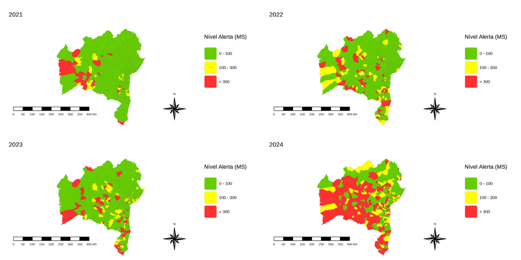

Figura 11: Distribuição espacial da dengue na Bahia (2021-2024) pelo critério de Semáforo do Ministério da Saúde.

A Figura 11 apresenta a classificação das taxas de incidência segundo os níveis de alerta adotados pelo Ministério da Saúde (MINISTÉRIO DA SAÚDE, 2016), que estabelece três categorias: baixa incidência (abaixo de 100 casos por 100 mil habitantes), alerta (entre 100 e 300 casos por 100 mil habitantes) e alta incidência (acima de 300 casos por 100 mil habitantes). Essa classificação permite uma interpretação mais direta do risco epidemiológico associado à dengue nos municípios baianos.

Em 2021, a maior parte dos municípios encontrava-se na categoria de baixa incidência, embora já fossem observados alguns municípios classificados nos níveis de alerta e alto risco. Em 2022 e 2023, verifica-se um aumento gradual da quantidade de municípios enquadrados nas categorias superiores, indicando a intensificação da circulação da doença em diferentes regiões do estado.

O cenário torna-se mais evidente em 2024, quando ocorre uma expansão expressiva dos municípios classificados na categoria de maior incidência. Além do aumento no número de municípios em situação de alerta, observa-se que diversas áreas vizinhas passaram a apresentar a mesma classificação, sugerindo a ocorrência de regiões com comportamento epidemiológico semelhante.

De modo geral, os mapas evidenciam o agravamento do cenário epidemiológico ao longo do período estudado e indicam que a distribuição da dengue apresenta uma organização espacial que merece investigação mais detalhada por meio das técnicas de autocorrelação espacial apresentadas nas seções seguintes.

## 5.4 Análise de Autocorrelação Espacial Global (Índice de Moran)

A Tabela 2 sintetiza os resultados do Índice de Moran Global $(I)$ para cada ano analisado, com avaliação de significância via permutação de Monte Carlo:

Tabela 2: Índice de Moran Global com teste de significância por permutação de Monte Carlo (999 simulações) — Bahia, 2021 a 2024.

| Ano | Índice de Moran Global (I) | p-valor |
| --- | --- | --- |
| 2021 | 0.2923 | 0,0010 |
| 2022 | 0.1094 | 0,0010 |
| 2023 | 0.0891 | 0,0120 |
| 2024 | 0.2713 | 0,0010 |

## 5.5 Diagramas de Dispersão de Moran

Os gráficos apresentados na Figura 12 mostram a relação entre as taxas de incidência observadas nos municípios e a média das taxas observadas em seus municípios vizinhos (lag espacial), para cada ano analisado. Cada ponto representa um município, enquanto a reta ajustada resume a tendência geral de associação espacial existente nos dados.

Municípios localizados nos quadrantes superior direito e inferior esquerdo tendem a apresentar comportamento semelhante ao de seus vizinhos, caracterizando associações espaciais positivas. Por outro lado, municípios posicionados nos quadrantes superior esquerdo e inferior direito representam situações em que os valores observados diferem do padrão predominante em sua vizinhança.

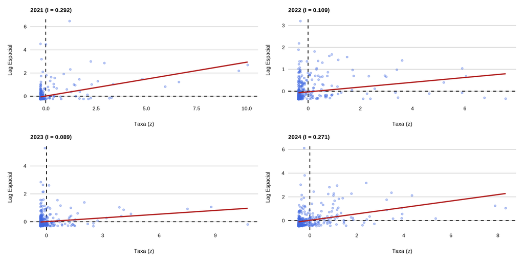

Figura 12: Diagramas de Dispersão de Moran para os anos de 2021 a 2024.

Observa-se que, em todos os anos analisados, a inclinação da reta é positiva, indicando a existência de autocorrelação espacial positiva entre as taxas de incidência de dengue. Isso significa que municípios com taxas elevadas tendem a estar próximos de municípios também com taxas elevadas, enquanto municípios com baixas taxas tendem a estar cercados por municípios com comportamento semelhante.

Os maiores valores do Índice de Moran foram observados em 2021 ($I = 0,292$) e 2024 ($I = 0,271$), evidenciando uma associação espacial moderada nesses anos. Em 2022 ($I = 0,109$) e 2023 ($I = 0,089$), embora a dependência espacial permaneça positiva, sua intensidade foi menor, sugerindo uma distribuição espacial mais dispersa das taxas de incidência.

Também é possível notar uma concentração expressiva de municípios próximos à origem dos gráficos, refletindo a predominância de taxas baixas ou moderadas na maior parte do estado. Entretanto, alguns municípios apresentam valores bastante superiores aos demais, posicionando-se mais distantes do centro da distribuição. Esses municípios contribuem para a heterogeneidade observada anteriormente na análise descritiva e reforçam a necessidade de identificar, por meio dos indicadores locais de associação espacial, se tais valores elevados estão inseridos em aglomerados espaciais ou se representam ocorrências isoladas.

## 5.6 Análise LISA (Moran Local)

Após a identificação de autocorrelação espacial global por meio do Índice de Moran, procedeu-se à análise dos Indicadores Locais de Associação Espacial (LISA) para os anos de 2021 a 2024. Essa abordagem permite identificar quais municípios contribuíram para os padrões de dependência espacial observados em escala global, bem como localizar possíveis aglomerados espaciais de alta e baixa incidência da doença.

Os resultados são apresentados nos mapas a seguir, nos quais cada município foi classificado de acordo com sua associação espacial em relação aos municípios vizinhos.

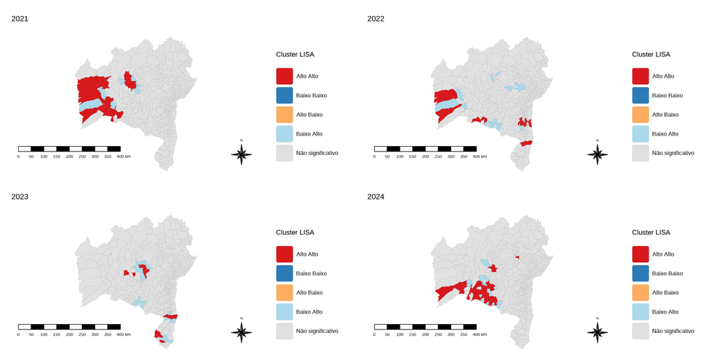

Figura 13: Clusters LISA de dengue na Bahia (2021-2024). Classificação dos municípios em Alto-Alto, Baixo-Baixo, Alto-Baixo, Baixo-Alto e Não Significativo.

Os mapas LISA permitem identificar a localização dos padrões locais de associação espacial observados entre os municípios baianos. Os agrupamentos classificados como Alto-Alto representam municípios com altas taxas de incidência cercados por municípios que também apresentam altas taxas, caracterizando áreas de maior concentração da doença. Por outro lado, os agrupamentos Baixo-Baixo correspondem a municípios com baixas taxas de incidência localizados próximos a municípios com comportamento semelhante.

De maneira geral, os resultados obtidos confirmam a existência de dependência espacial na distribuição da dengue entre os municípios baianos, corroborando os resultados observados por meio do Índice de Moran Global. A presença de agrupamentos espacialmente definidos indica que a ocorrência da doença não se distribui de forma aleatória no território, mas tende a apresentar padrões de concentração em determinadas regiões do estado (COELHO; ANVERSA; *et al.*, 2022; SILVA; SANTOS, 2021).

Observa-se ainda que os padrões espaciais identificados variam ao longo dos anos analisados, acompanhando as mudanças observadas nos níveis de incidência da doença. Em 2024, ano que apresentou uma das maiores magnitudes de autocorrelação espacial e os maiores níveis de incidência, verificou-se também a presença de agrupamentos mais extensos de municípios com elevadas taxas de dengue.

Esses resultados reforçam a importância da incorporação da dimensão espacial em estudos epidemiológicos, uma vez que permitem identificar áreas com comportamento semelhante e subsidiar ações de vigilância e controle mais direcionadas às regiões com maior concentração da doença.

# 6 Conclusões

A análise da incidência de dengue nos municípios do estado da Bahia entre 2021 e 2024 permitiu identificar mudanças importantes no comportamento da doença ao longo do período estudado. Os resultados descritivos evidenciaram um aumento das taxas de incidência, com destaque para o ano de 2024, que apresentou os maiores valores observados. Também foi verificada elevada variabilidade entre os municípios, indicando que a ocorrência da doença não se distribuiu de forma uniforme no território baiano.

A aplicação das técnicas de análise espacial possibilitou investigar a existência de dependência espacial na distribuição das taxas de incidência. Os resultados do Índice de Moran Global indicaram autocorrelação espacial positiva e estatisticamente significativa em todos os anos analisados, evidenciando que municípios com comportamento semelhante tendem a se localizar próximos uns dos outros.

De forma geral, os resultados indicam que a distribuição espacial da dengue na Bahia não ocorreu de maneira aleatória, apresentando padrões de associação espacial que variaram ao longo dos anos analisados. Essas informações podem contribuir para o direcionamento das ações de vigilância epidemiológica e controle da doença, permitindo identificar áreas que demandam maior atenção por parte dos gestores públicos.

Como perspectiva para trabalhos futuros, recomenda-se a incorporação de variáveis socioeconômicas, demográficas e ambientais, visando compreender os fatores associados aos padrões espaciais observados e aprofundar o entendimento da dinâmica de transmissão da dengue no estado da Bahia.

# 7 Referências

ALMEIDA, Alexandre Soares de; MEDRONHO, Roberto de Andrade; VALENCIA, Livia Insês Oliveira Ferreira. [Análise espacial da dengue e o contexto socioeconômico no município do Rio de Janeiro, RJ](https://doi.org/10.1590/S0034-89102009000400013). **Revista de Saúde Pública**. v. 43, n. 4, p.666–673, 2009.

ANSELIN, Luc. [Local indicators of spatial association — LISA](https://doi.org/10.1111/j.1538-4632.1995.tb00338.x). **Geographical Analysis**. v. 27, n. 2, p.93–115, 1995.

ARAÚJO, Maria Josiane Santos; MELO, Ana Carolina Oliveira; MORAES, Ronei Marcos. [Análise espacial da distribuição dos casos de dengue e sua relação com fatores socioambientais no estado da Paraíba, Brasil, 2007–2016](https://doi.org/10.1590/0103-1104202012513). **Saúde em Debate**. v. 44, n. 125, p.465–477, 2020.

BIVAND, Roger S.; PEBESMA, Edzer; GÓMEZ-RUBIO, Virgilio. **[Applied Spatial Data Analysis with R](https://doi.org/10.1007/978-1-4614-7618-4)**. 2º ed. New York: Springer. 2013.

COELHO, Sueli Viviane; ANVERSA, Leticia; *et al.* [Temporal and spatial analysis of municipal dengue cases in Paraná and social and environmental indicators, 2012 to 2021: ecological study](https://doi.org/10.1590/1980-549720220049). **Revista Brasileira de Epidemiologia**. 2022.

CRESSIE, Noel A. C. **Statistics for Spatial Data**. Revised. New York: Wiley. 1993.

GOOD, Phillip. **[Permutation, Parametric and Bootstrap Tests of Hypotheses](https://doi.org/10.1007/b138696)**. 3º ed. New York: Springer. 2005.

HALSTEAD, Scott B. Dengue. **The Lancet**. v. 370, n. 9599, p.1644–1652, 2007.

HOPE, A. C. A. [A simplified Monte Carlo significance test procedure](https://doi.org/10.1111/j.2517-6161.1968.tb00759.x). **Journal of the Royal Statistical Society: Series B**. v. 30, n. 3, p.582–598, 1968.

MEDEIROS, Elias Silva de *et al.* [Modeling Spatiotemporal Rainfall Variability in Paraíba, Brazil](https://doi.org/10.3390/w11091843). **Water**. v. 11, n. 9, p.1843, 2019.

MINISTÉRIO DA SAÚDE. **Dengue: diagnóstico e manejo clínico — adulto e criança**. Brasília: Secretaria de Vigilância em Saúde, Ministério da Saúde. 2016.

MINISTÉRIO DA SAÚDE. **Painel de Monitoramento das Arboviroses**. Brasília: Secretaria de Vigilância em Saúde e Ambiente, Ministério da Saúde. 2024. Disponível em: https://www.gov.br/saude/pt-br/assuntos/saude-de-a-a-z/a/arboviroses/monitoramento.

MORAGA, Paula. **Spatial Statistics for Data Science: Theory and Practice with R**. Chapman; Hall/CRC. 2023.

OLINDA, Ricardo Alves de *et al.* Estudo de simulação de extremos espaciais com base em processos max-stable. **Revista Brasileira de Biometria**. v. 31, n. 1, p.132–156, 2013.

ORGANIZAÇÃO PAN-AMERICANA DA SAÚDE. **Dengue: guías para la atención de enfermos en la región de las Américas**. Washington, D.C.: OPAS/OMS. 2016. Disponível em: https://iris.paho.org/handle/10665.2/28232.

PFEIFFER, Dirk U. *et al.* **Spatial Analysis in Epidemiology**. Oxford: Oxford University Press. 2008.

R CORE TEAM. **R: A Language and Environment for Statistical Computing**. Vienna, Austria: R Foundation for Statistical Computing. 2024. Disponível em: https://www.R-project.org/.

RIPSA – REDE INTERAGENCIAL DE INFORMAÇÕES PARA A SAÚDE. **Taxa de incidência de dengue – Ficha de qualificação D.2.3**. Brasília: Ministério da Saúde / OPAS. 2000. Disponível em: http://tabnet.datasus.gov.br/tabdata/LivroIDB/2edrev/d0203.pdf.

SILVA, Eliane Oliveira da; SANTOS, Laís Ferrari dos. Dengue na Bahia: análise espaço-temporal entre os anos de 2007 e 2017. **Revista de Saúde Coletiva da UEFS**. 2021. Disponível em: https://periodicos.uefs.br/index.php/saudecoletiva/article/view/7189.

TUKEY, John W. **Exploratory Data Analysis**. Reading, MA: Addison-Wesley. 1977.

WALLER, Lance A.; GOTWAY, Carol A. **[Applied Spatial Statistics for Public Health Data](https://doi.org/10.1002/0471662682)**. Hoboken: Wiley. 2004.

## 8 Anexo — Listagem de Comandos Utilizados

Esta seção apresenta os principais blocos de código R utilizados na análise.

**ver código**

```r
# ── Pacotes utilizados
use("dplyr", "tidyr", "knitr", "kableExtra", "readr", "ggplot2",
    "patchwork", "scales", "shadowtext", "spdep", "sf", "tmap")

# ── Leitura dos dados
# Caminhos ancorados no diretório do .qmd
.raiz <- if (file.exists(file.path(getwd(), "outputs"))) getwd() else file.path(getwd(), "..")
dir_outputs <- file.path(.raiz, "outputs")
dir_taxa    <- file.path(.raiz, "dataset",
                         "dados_taxa_100k_hab_casos_dengue_por_municipio_bahia",
                         "dataset_processado")

taxa_completa <- read_csv(
  file.path(dir_taxa, "taxa_casos_dengue_BA_2007_2025.csv"),
  col_types = cols(.default = "c"),
  show_col_types = FALSE
) |>
  mutate(
    ano           = as.integer(ano),
    n_casos       = as.numeric(n_casos),
    populacao     = as.numeric(populacao),
    taxa_100k_hab = as.numeric(taxa_100k_hab)
  )

# Dados espaciais (shapefile + taxas por ano)
shape_por_ano <- readRDS(file.path(dir_outputs, "shape_por_ano_ba.rds"))

# Matriz de vizinhança (Queen, padronizada por linha)
viz          <- readRDS(file.path(dir_outputs, "vizinhanca_ba.rds"))
vizinhanca_w <- viz$vizinhanca_w

# ── Estatísticas descritivas
serie_hist <- taxa_completa |>
  group_by(ano) |>
  summarise(
    total_casos_ano = sum(n_casos, na.rm = TRUE),
    taxa_media_ano  = mean(taxa_100k_hab, na.rm = TRUE),
    .groups = "drop"
  )

tabela <- read_csv("../outputs/tabela_estatistica_descritiva_2021_2024.csv",
                   show_col_types = FALSE)

# ── I de Moran Global (Monte Carlo, 999 permutações)
anos <- c("2021", "2022", "2023", "2024")

resultados_moran <- lapply(anos, function(a) {
  taxa_a <- shape_por_ano[[a]]$taxa_100k_hab
  taxa_a[is.na(taxa_a)] <- 0
  set.seed(42)
  teste <- moran.mc(taxa_a, vizinhanca_w, nsim = 999, zero.policy = TRUE)
  data.frame(
    Ano           = a,
    `I de Moran`  = round(teste$statistic, 4),
    `p valor`     = ifelse(teste$p.value < 0.001, "< 0,001",
                      gsub("\\.", ",", format(round(teste$p.value, 4), nsmall = 4))),
    Significativo = ifelse(teste$p.value < 0.05, "Sim", "Não")
  )
}) |> bind_rows()

# ── Diagramas de dispersão de Moran
moran_plot_gg <- function(sf_ano, ano_label, vizinhanca_w) {
  taxa  <- sf_ano$taxa_100k_hab
  taxa[is.na(taxa)] <- 0
  z     <- as.numeric(scale(taxa))
  lag_z <- lag.listw(vizinhanca_w, z, zero.policy = TRUE)
  I_val <- round(moran(z, vizinhanca_w, length(z),
                       Szero(vizinhanca_w), zero.policy = TRUE)$I, 3)
  ggplot(data.frame(z = z, lag_z = lag_z), aes(x = z, y = lag_z)) +
    geom_hline(yintercept = 0, color = "gray70", linetype = "dashed") +
    geom_vline(xintercept = 0, color = "gray70", linetype = "dashed") +
    geom_point(alpha = 0.35, size = 1.0, color = "steelblue") +
    geom_smooth(method = "lm", se = FALSE, color = "firebrick", linewidth = 0.8) +
    labs(title = paste0(ano_label, " (I = ", I_val, ")"),
         x = "Taxa (z)", y = "Lag Espacial") +
    theme_minimal()}

p21 <- moran_plot_gg(shape_por_ano[["2021"]], "2021", vizinhanca_w)
p22 <- moran_plot_gg(shape_por_ano[["2022"]], "2022", vizinhanca_w)
p23 <- moran_plot_gg(shape_por_ano[["2023"]], "2023", vizinhanca_w)
p24 <- moran_plot_gg(shape_por_ano[["2024"]], "2024", vizinhanca_w)

(p21 | p22) / (p23 | p24)

# ── Análise LISA (Moran Local) — 2024
sf_lisa    <- shape_por_ano[["2024"]]
taxa_bruta <- replace(sf_lisa$taxa_100k_hab, is.na(sf_lisa$taxa_100k_hab), 0)
set.seed(42)
local_m <- localmoran(taxa_bruta, vizinhanca_w, zero.policy = TRUE)

sf_lisa$li_pvalor <- local_m[, "Pr(z != E(Ii))"]
taxa_z            <- as.numeric(scale(taxa_bruta))
sf_lisa$lag_z     <- lag.listw(vizinhanca_w, taxa_z, zero.policy = TRUE)
sf_lisa$taxa_z    <- taxa_z

sf_lisa <- sf_lisa |>
  mutate(
    quadrante = case_when(
      taxa_z > 0 & lag_z > 0 & li_pvalor < 0.05 ~ "Alto Alto",
      taxa_z < 0 & lag_z < 0 & li_pvalor < 0.05 ~ "Baixo Baixo",
      taxa_z > 0 & lag_z < 0 & li_pvalor < 0.05 ~ "Alto Baixo",
      taxa_z < 0 & lag_z > 0 & li_pvalor < 0.05 ~ "Baixo Alto",
      TRUE ~ "Não significativo"
    ),
    quadrante = factor(quadrante,
                       levels = c("Alto Alto", "Baixo Baixo",
                                  "Alto Baixo", "Baixo Alto", "Não significativo")))

cores_lisa <- c("Alto Alto" = "#d7191c", "Baixo Baixo" = "#2c7bb6",
                "Alto Baixo" = "#fdae61", "Baixo Alto" = "#abd9e9",
                "Não significativo" = "gray88")

tm_shape(sf_lisa) +
  tm_polygons(
    fill = "quadrante",
    fill.scale  = tm_scale_categorical(values = cores_lisa),
    fill.legend = tm_legend(title = "Cluster LISA", text.size = 0.6),
    col = "gray50", lwd = 0.1) +
  tm_layout(frame = FALSE,
            main.title      = "Clusters LISA: Dengue na Bahia (2024)",
            main.title.size = 0.8)
```